# Part I - Ford GoBike System Data Exploration

## Introduction

> This data set includes information about individual rides made in a bike-sharing system covering the greater San Francisco Bay area in February 2019.

## Preliminary Wrangling

```python
# import all packages and set plots to be embedded inline
import numpy as np
import pandas as pd
import matplotlib.pyplot as plt
import seaborn as sb

%matplotlib inline
```

```python
#Importing the dataset
df = pd.read_csv(r'C:\Users\USER\Desktop\201902-fordgobike-tripdata.csv')
```

```python
#Viewing the first 5 rows

df.head()
```

|  | duration_sec | start_time | end_time | start_station_id | start_station_name | start_station_latitude | start_station_longitude | end_station_id | end_station_name | end_station_latitude | end_station_longitude | bike_id | user_type | member_birth_year | member_gender | bike_share_for_all_trip |
| --- | --- | --- | --- | --- | --- | --- | --- | --- | --- | --- | --- | --- | --- | --- | --- | --- |
| 0 | 52185 | 2019-02-28 17:32:10.1450 | 2019-03-01 08:01:55.9750 | 21.0 | Montgomery St BART Station (Market St at 2nd St) | 37.789625 | -122.400811 | 13.0 | Commercial St at Montgomery St | 37.794231 | -122.402923 | 4902 | Customer | 1984.0 | Male | No |
| 1 | 42521 | 2019-02-28 18:53:21.7890 | 2019-03-01 06:42:03.0560 | 23.0 | The Embarcadero at Steuart St | 37.791464 | -122.391034 | 81.0 | Berry St at 4th St | 37.775880 | -122.393170 | 2535 | Customer | NaN | NaN | No |
| 2 | 61854 | 2019-02-28 12:13:13.2180 | 2019-03-01 05:24:08.1460 | 86.0 | Market St at Dolores St | 37.769305 | -122.426826 | 3.0 | Powell St BART Station (Market St at 4th St) | 37.786375 | -122.404904 | 5905 | Customer | 1972.0 | Male | No |
| 3 | 36490 | 2019-02-28 17:54:26.0100 | 2019-03-01 04:02:36.8420 | 375.0 | Grove St at Masonic Ave | 37.774836 | -122.446546 | 70.0 | Central Ave at Fell St | 37.773311 | -122.444293 | 6638 | Subscriber | 1989.0 | Other | No |
| 4 | 1585 | 2019-02-28 23:54:18.5490 | 2019-03-01 00:20:44.0740 | 7.0 | Frank H Ogawa Plaza | 37.804562 | -122.271738 | 222.0 | 10th Ave at E 15th St | 37.792714 | -122.248780 | 4898 | Subscriber | 1974.0 | Male | Yes |

```python
#Viewing a sample

df.sample(7)
```

|  | duration_sec | start_time | end_time | start_station_id | start_station_name | start_station_latitude | start_station_longitude | end_station_id | end_station_name | end_station_latitude | end_station_longitude | bike_id | user_type | member_birth_year | member_gender | bike_share_for_all_trip |
| --- | --- | --- | --- | --- | --- | --- | --- | --- | --- | --- | --- | --- | --- | --- | --- | --- |
| 82650 | 562 | 2019-02-18 09:29:30.0080 | 2019-02-18 09:38:52.7310 | 77.0 | 11th St at Natoma St | 37.773507 | -122.416040 | 20.0 | Mechanics Monument Plaza (Market St at Bush St) | 37.791300 | -122.399051 | 5218 | Subscriber | 1978.0 | Male | No |
| 70814 | 558 | 2019-02-19 17:56:33.0400 | 2019-02-19 18:05:51.0690 | 22.0 | Howard St at Beale St | 37.789756 | -122.394643 | 60.0 | 8th St at Ringold St | 37.774520 | -122.409449 | 4767 | Subscriber | 1992.0 | Male | No |
| 20183 | 351 | 2019-02-26 13:50:40.3770 | 2019-02-26 13:56:32.0040 | 5.0 | Powell St BART Station (Market St at 5th St) | 37.783899 | -122.408445 | 62.0 | Victoria Manalo Draves Park | 37.777791 | -122.406432 | 6588 | Subscriber | 1994.0 | Male | No |
| 73411 | 355 | 2019-02-19 13:54:15.1990 | 2019-02-19 14:00:11.0510 | 129.0 | Harrison St at 20th St | 37.758862 | -122.412544 | 98.0 | Valencia St at 16th St | 37.765052 | -122.421866 | 5849 | Subscriber | 1980.0 | Male | No |
| 121500 | 329 | 2019-02-11 15:06:39.4990 | 2019-02-11 15:12:09.1200 | 256.0 | Hearst Ave at Euclid Ave | 37.875112 | -122.260553 | 258.0 | University Ave at Oxford St | 37.872355 | -122.266447 | 4506 | Subscriber | 2000.0 | Female | Yes |
| 38149 | 117 | 2019-02-23 12:42:21.5720 | 2019-02-23 12:44:19.2170 | 116.0 | Mississippi St at 17th St | 37.764802 | -122.394771 | 104.0 | 4th St at 16th St | 37.767045 | -122.390833 | 6133 | Subscriber | 1978.0 | Male | No |
| 20276 | 471 | 2019-02-26 13:22:59.2570 | 2019-02-26 13:30:50.5190 | 299.0 | Bestor Art Park | 37.323678 | -121.874119 | 310.0 | San Fernando St at 4th St | 37.335885 | -121.885660 | 421 | Subscriber | 1986.0 | Male | Yes |

```python
#Viewing the data summary

df.info()
```

```
<class 'pandas.core.frame.DataFrame'>
RangeIndex: 183412 entries, 0 to 183411
Data columns (total 16 columns):
 #   Column                   Non-Null Count   Dtype
---  ------                   --------------   -----
 0   duration_sec             183412 non-null  int64
 1   start_time               183412 non-null  object
 2   end_time                 183412 non-null  object
 3   start_station_id         183215 non-null  float64
 4   start_station_name       183215 non-null  object
 5   start_station_latitude   183412 non-null  float64
 6   start_station_longitude  183412 non-null  float64
 7   end_station_id           183215 non-null  float64
 8   end_station_name         183215 non-null  object
 9   end_station_latitude     183412 non-null  float64
 10  end_station_longitude    183412 non-null  float64
 11  bike_id                  183412 non-null  int64
 12  user_type                183412 non-null  object
 13  member_birth_year        175147 non-null  float64
 14  member_gender            175147 non-null  object
 15  bike_share_for_all_trip  183412 non-null  object
dtypes: float64(7), int64(2), object(7)
memory usage: 22.4+ MB
```

```python
#creating a copy for the dataset
df_copy = df.copy()
```

```python
#changing data type of start_time and end_time to datetime
df_copy['start_time'] = pd.to_datetime(df_copy['start_time'])
df_copy['end_time'] = pd.to_datetime(df_copy['end_time'])
```

```python
df_copy.info()
```

```
<class 'pandas.core.frame.DataFrame'>
RangeIndex: 183412 entries, 0 to 183411
Data columns (total 16 columns):
 #   Column                   Non-Null Count   Dtype
---  ------                   --------------   -----
 0   duration_sec             183412 non-null  int64
 1   start_time               183412 non-null  datetime64[ns]
 2   end_time                 183412 non-null  datetime64[ns]
 3   start_station_id         183215 non-null  float64
 4   start_station_name       183215 non-null  object
 5   start_station_latitude   183412 non-null  float64
 6   start_station_longitude  183412 non-null  float64
 7   end_station_id           183215 non-null  float64
 8   end_station_name         183215 non-null  object
 9   end_station_latitude     183412 non-null  float64
 10  end_station_longitude    183412 non-null  float64
 11  bike_id                  183412 non-null  int64
 12  user_type                183412 non-null  object
 13  member_birth_year        175147 non-null  float64
 14  member_gender            175147 non-null  object
 15  bike_share_for_all_trip  183412 non-null  object
dtypes: datetime64[ns](2), float64(7), int64(2), object(5)
memory usage: 22.4+ MB
```

```python
#Converting end_station_id, bike_id and start_station_id into strings

df_copy['end_station_id'] = df_copy['end_station_id'].astype(str)
df_copy['bike_id'] = df_copy['bike_id'].astype(str)
df_copy['start_station_id'] = df_copy['start_station_id'].astype(str)
```

```python
df_copy.info()
```

```
<class 'pandas.core.frame.DataFrame'>
RangeIndex: 183412 entries, 0 to 183411
Data columns (total 16 columns):
 #   Column                   Non-Null Count   Dtype
---  ------                   --------------   -----
 0   duration_sec             183412 non-null  int64
 1   start_time               183412 non-null  datetime64[ns]
 2   end_time                 183412 non-null  datetime64[ns]
 3   start_station_id         183412 non-null  object
 4   start_station_name       183215 non-null  object
 5   start_station_latitude   183412 non-null  float64
 6   start_station_longitude  183412 non-null  float64
 7   end_station_id           183412 non-null  object
 8   end_station_name         183215 non-null  object
 9   end_station_latitude     183412 non-null  float64
 10  end_station_longitude    183412 non-null  float64
 11  bike_id                  183412 non-null  object
 12  user_type                183412 non-null  object
 13  member_birth_year        175147 non-null  float64
 14  member_gender            175147 non-null  object
 15  bike_share_for_all_trip  183412 non-null  object
dtypes: datetime64[ns](2), float64(5), int64(1), object(8)
memory usage: 22.4+ MB
```

```python
df_copy.columns
```

```
Index(['duration_sec', 'start_time', 'end_time', 'start_station_id',
       'start_station_name', 'start_station_latitude',
       'start_station_longitude', 'end_station_id', 'end_station_name',
       'end_station_latitude', 'end_station_longitude', 'bike_id', 'user_type',
       'member_birth_year', 'member_gender', 'bike_share_for_all_trip'],
      dtype='object')
```

```python
df_copy.shape
```

```
(183412, 16)
```

```python
#dropping all na in the dataset

df_copy.dropna(inplace = True)
```

```python
df_copy.info()
```

```
<class 'pandas.core.frame.DataFrame'>
Int64Index: 174952 entries, 0 to 183411
Data columns (total 16 columns):
 #   Column                   Non-Null Count   Dtype
---  ------                   --------------   -----
 0   duration_sec             174952 non-null  int64
 1   start_time               174952 non-null  datetime64[ns]
 2   end_time                 174952 non-null  datetime64[ns]
 3   start_station_id         174952 non-null  object
 4   start_station_name       174952 non-null  object
 5   start_station_latitude   174952 non-null  float64
 6   start_station_longitude  174952 non-null  float64
 7   end_station_id           174952 non-null  object
 8   end_station_name         174952 non-null  object
 9   end_station_latitude     174952 non-null  float64
 10  end_station_longitude    174952 non-null  float64
 11  bike_id                  174952 non-null  object
 12  user_type                174952 non-null  object
 13  member_birth_year        174952 non-null  float64
 14  member_gender            174952 non-null  object
 15  bike_share_for_all_trip  174952 non-null  object
dtypes: datetime64[ns](2), float64(5), int64(1), object(8)
memory usage: 22.7+ MB
```

### What is the structure of your dataset?

> There are 183412 trips and 16 columns in the dataset with information such as duration of the ride in seconds, start and end station names, logitude and latitude as well as information on users.

### What is/are the main feature(s) of interest in your dataset?

> The trip duration and factors that influences it

### What features in the dataset do you think will help support your investigation into your feature(s) of interest?

> The loation of start and end stations, user type and gender should influnce trip duration.

## Univariate Exploration

```python
#How long do most trips last?
```

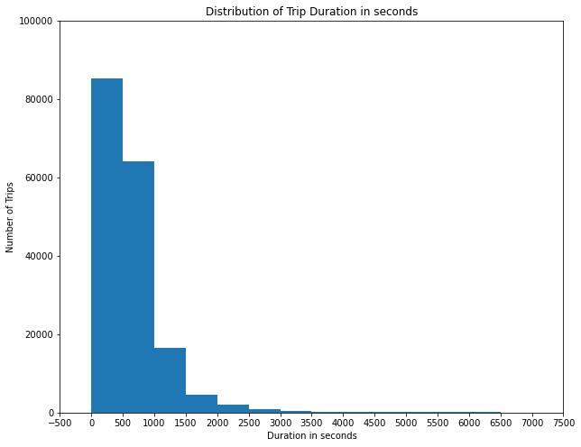

```python
binsize = 500
bins = np.arange(0, df_copy['duration_sec'].max()+binsize, binsize)

plt.figure(figsize=[10, 8])
plt.hist(data = df_copy, x = 'duration_sec', bins = bins)
plt.title('Distribution of Trip Duration in seconds')
plt.xlabel('Duration in seconds')
plt.ylabel('Number of Trips')
plt.axis([-500, 7000, 0, 100000])
plt.xticks(range(-500, 8000, 500))
plt.yticks(range(0,120000,20000))
plt.show()
```

```python
#From the histogram above, we can see that most trips last below 1000 seconds. Let us see how it will be distirbuted in minutes
```

```python
#creating a minutes column
df_copy['duration_minutes'] = df_copy['duration_sec']/60
```

```python
df_copy.sample(5)
```

|  | duration_sec | start_time | end_time | start_station_id | start_station_name | start_station_latitude | start_station_longitude | end_station_id | end_station_name | end_station_latitude | end_station_longitude | bike_id | user_type | member_birth_year | member_gender | bike_share_for_all_trip | duration_minutes |
| --- | --- | --- | --- | --- | --- | --- | --- | --- | --- | --- | --- | --- | --- | --- | --- | --- | --- |
| 175275 | 340 | 2019-02-02 14:55:35.979 | 2019-02-02 15:01:16.580 | 89.0 | Division St at Potrero Ave | 37.769218 | -122.407646 | 50.0 | 2nd St at Townsend St | 37.780526 | -122.390288 | 5423 | Subscriber | 1992.0 | Male | No | 5.666667 |
| 82589 | 905 | 2019-02-18 09:35:44.101 | 2019-02-18 09:50:49.868 | 180.0 | Telegraph Ave at 23rd St | 37.812678 | -122.268773 | 191.0 | Market St at 40th St | 37.830545 | -122.273937 | 2339 | Subscriber | 1970.0 | Female | No | 15.083333 |
| 117805 | 349 | 2019-02-11 20:17:03.098 | 2019-02-11 20:22:52.828 | 129.0 | Harrison St at 20th St | 37.758862 | -122.412544 | 381.0 | 20th St at Dolores St | 37.758238 | -122.426094 | 5137 | Subscriber | 1987.0 | Male | No | 5.816667 |
| 85411 | 1943 | 2019-02-17 14:51:59.669 | 2019-02-17 15:24:23.551 | 13.0 | Commercial St at Montgomery St | 37.794231 | -122.402923 | 371.0 | Lombard St at Columbus Ave | 37.802746 | -122.413579 | 6512 | Customer | 1993.0 | Male | No | 32.383333 |
| 113850 | 1135 | 2019-02-12 10:32:23.432 | 2019-02-12 10:51:18.528 | 71.0 | Broderick St at Oak St | 37.773063 | -122.439078 | 26.0 | 1st St at Folsom St | 37.787290 | -122.394380 | 4658 | Subscriber | 1980.0 | Male | Yes | 18.916667 |

```python
#Converting to integer
df_copy['duration_minutes'] = df_copy['duration_minutes'].astype(int)
```

```python
df_copy.sample()
```

|  | duration_sec | start_time | end_time | start_station_id | start_station_name | start_station_latitude | start_station_longitude | end_station_id | end_station_name | end_station_latitude | end_station_longitude | bike_id | user_type | member_birth_year | member_gender | bike_share_for_all_trip | duration_minutes |
| --- | --- | --- | --- | --- | --- | --- | --- | --- | --- | --- | --- | --- | --- | --- | --- | --- | --- |
| 181791 | 285 | 2019-02-01 08:55:54.310 | 2019-02-01 09:00:39.348 | 25.0 | Howard St at 2nd St | 37.787522 | -122.397405 | 349.0 | Howard St at Mary St | 37.78101 | -122.405666 | 3670 | Subscriber | 1987.0 | Male | No | 4 |

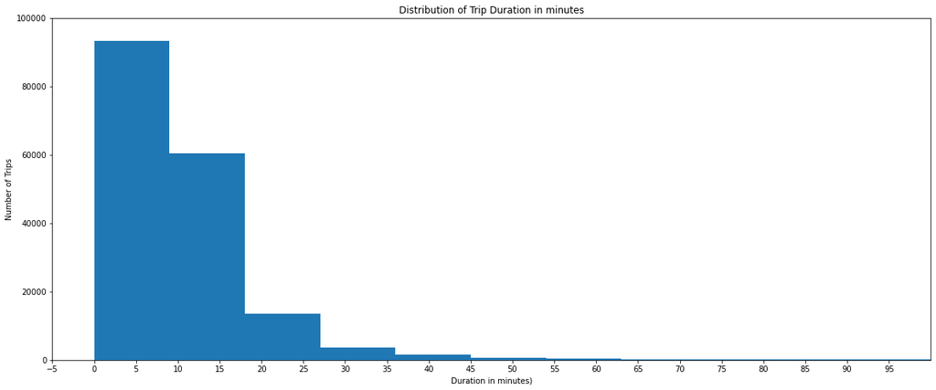

```python
binsize = 9
bins = np.arange(0, df_copy['duration_minutes'].max()+binsize, binsize)

plt.figure(figsize=[20, 8])
plt.hist(data = df_copy, x = 'duration_minutes', bins = bins)
plt.title('Distribution of Trip Duration in minutes')
plt.xlabel('Duration in minutes)')
plt.ylabel('Number of Trips')
plt.axis([-5, 100, 0, 100000])
plt.xticks(range(-5,100,5))
plt.yticks(range(0,120000,20000))
plt.show()
```

```python
#Going deeper in minutes, we can see most common trip lasts between 0-10 minutes
```

```python
#What age range takes the most trips?

#Creating an age column
```

```python
df_copy['member_age'] = 2022 - df_copy['member_birth_year']

df_copy.sample(5)
```

|  | duration_sec | start_time | end_time | start_station_id | start_station_name | start_station_latitude | start_station_longitude | end_station_id | end_station_name | end_station_latitude | end_station_longitude | bike_id | user_type | member_birth_year | member_gender | bike_share_for_all_trip | duration_minutes | member_age |
| --- | --- | --- | --- | --- | --- | --- | --- | --- | --- | --- | --- | --- | --- | --- | --- | --- | --- | --- |
| 100729 | 263 | 2019-02-14 18:10:30.763 | 2019-02-14 18:14:54.503 | 160.0 | West Oakland BART Station | 37.805318 | -122.294837 | 230.0 | 14th St at Mandela Pkwy | 37.810743 | -122.291415 | 4494 | Subscriber | 1987.0 | Male | No | 4 | 35.0 |
| 40497 | 554 | 2019-02-22 20:34:13.007 | 2019-02-22 20:43:27.197 | 133.0 | Valencia St at 22nd St | 37.755213 | -122.420975 | 95.0 | Sanchez St at 15th St | 37.766219 | -122.431060 | 6113 | Subscriber | 1986.0 | Female | No | 9 | 36.0 |
| 114939 | 778 | 2019-02-12 08:58:51.428 | 2019-02-12 09:11:50.135 | 139.0 | Garfield Square (25th St at Harrison St) | 37.751017 | -122.411901 | 89.0 | Division St at Potrero Ave | 37.769218 | -122.407646 | 2868 | Subscriber | 1983.0 | Male | No | 12 | 39.0 |
| 122176 | 576 | 2019-02-11 12:40:44.189 | 2019-02-11 12:50:20.577 | 107.0 | 17th St at Dolores St | 37.763015 | -122.426497 | 90.0 | Townsend St at 7th St | 37.771058 | -122.402717 | 4372 | Subscriber | 1989.0 | Female | No | 9 | 33.0 |
| 14718 | 435 | 2019-02-27 11:21:33.345 | 2019-02-27 11:28:48.449 | 296.0 | 5th St at Virginia St | 37.325998 | -121.877120 | 310.0 | San Fernando St at 4th St | 37.335885 | -121.885660 | 5644 | Subscriber | 1995.0 | Male | Yes | 7 | 27.0 |

```python
#Converting to integer
df_copy['member_age'] = df_copy['member_age'].astype(int)
```

```python
df_copy.sample(5)
```

|  | duration_sec | start_time | end_time | start_station_id | start_station_name | start_station_latitude | start_station_longitude | end_station_id | end_station_name | end_station_latitude | end_station_longitude | bike_id | user_type | member_birth_year | member_gender | bike_share_for_all_trip | duration_minutes | member_age |
| --- | --- | --- | --- | --- | --- | --- | --- | --- | --- | --- | --- | --- | --- | --- | --- | --- | --- | --- |
| 60412 | 257 | 2019-02-20 18:44:31.333 | 2019-02-20 18:48:48.743 | 44.0 | Civic Center/UN Plaza BART Station (Market St ... | 37.781074 | -122.411738 | 3.0 | Powell St BART Station (Market St at 4th St) | 37.786375 | -122.404904 | 5017 | Subscriber | 1965.0 | Male | Yes | 4 | 57 |
| 32926 | 3350 | 2019-02-24 12:26:40.759 | 2019-02-24 13:22:31.702 | 201.0 | 10th St at Fallon St | 37.797673 | -122.262997 | 201.0 | 10th St at Fallon St | 37.797673 | -122.262997 | 4682 | Subscriber | 1975.0 | Male | Yes | 55 | 47 |
| 78952 | 8623 | 2019-02-18 16:03:52.854 | 2019-02-18 18:27:36.315 | 95.0 | Sanchez St at 15th St | 37.766219 | -122.431060 | 377.0 | Fell St at Stanyan St | 37.771917 | -122.453704 | 5369 | Customer | 1988.0 | Male | No | 143 | 34 |
| 38341 | 734 | 2019-02-23 12:07:23.582 | 2019-02-23 12:19:38.368 | 144.0 | Precita Park | 37.747300 | -122.411403 | 105.0 | 16th St at Prosper St | 37.764285 | -122.431804 | 5719 | Subscriber | 1975.0 | Male | No | 12 | 47 |
| 33349 | 1790 | 2019-02-24 11:42:43.464 | 2019-02-24 12:12:33.545 | 176.0 | MacArthur BART Station | 37.828410 | -122.266315 | 265.0 | Ninth St at Parker St | 37.858868 | -122.291209 | 5707 | Customer | 1974.0 | Male | No | 29 | 48 |